# ames iowa kaggle home price modeling

preeti swaminathan & patrick mcdevitt

14 avril 2017

## House Prices - à la Kaggle - Homework 13

### Analysis Question 2

#### **Statement of Problem**

Estimating market value of a home for sale has significant implications for all parties involved in the transaction : seller, buyer, agents, mortgage providers and even local taxing authorities. Getting it right can improve local economies. Inefficiencies associated to historical methods of value assessments create hesitation on the part of buyers and lenders, and potential loss of revenue for sellers and agents. Developing a model that considers all available factors and provides a transparent valuation that can be shared among all parties in the transaction can enable the participants to proceed with increased confidence, thus increasing the velocity of the local real estate market.  
That is the purpose of this evaluation : use all available contributing factors for the residnetial real estate market in Ames, Iowa and create a predicitve model to better estimate market valuation for future properties to be proposed for sale.

#### **Data Available & Utilized**

For this evaluation, there are seventy-nine explanatory variables available for exploitation, based on residential sales in the years 2006 trough 2010, comprising approximately 1500 sales. The explanatory variables include traditional expected characteristics, such as : neighborhood, square footage, number of bedrooms, number of bathrooms, etc. and also several factors that are perhaps considered secondary or tertiary, but are included in the modeling to increase predictive capability. Some of these additional factors include : heating type, number of fireplaces, qualitative assessment of the kitchen condition.

#### **Model Construction**

In order to build the model, the following steps are taken :  
* read in the raw training data set provided,  
* basic cleaning of the data, including removing significant outliers (for this purpose, more than 5 std deviations from mean)  
* imputing values for features where none was provided (for this purpose, setting to mean value for numeric features, and creating a new factor level “None” for categorical features),  
* plot and visually examine each feature in relation to log(SalePrice) …  
+ this provides a basis for removing some features from consideration based on inspection  
+ some features may have 1400 / 1460 within same cateegory, thus not providing varaibility worthwhile including in a model  
+ some numerical features are sparsely populated, and the the few values visually exhibit zero slope in relation to log(SalePrice)  
+ a new feature was created “saledate” from the “year sold” and “month sold” features. Upon visual examination, there was no obvious trend in the time series view for log(SalePrice)s, so this was eventually discarded (surprisingly, considering that the time period spanned the economic downturn to 2007 - 2009).  
+ this visual examination then results in eliminating approximately 25 of the features from consideration in the model.  
+ (All of the plots are available for review in the appendix, “homes_train_plots.pdf”, if desired for review)

#### **Models Considered**

Four different models are built :  
* Stepwise - modeled in SAS proc glmselect  
* Forward - modeled in SAS proc glmselect  
* Backward - modeled in SAS proc glmselect  
* CUSTOM - this method using an iterative loop to evaluate the VIF for each contributor in the current model, eliminates the feature with the highest VIF, and continues until max(VIF) remaining in the model is < 5

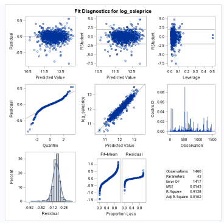

Residual Plots - SAS Stepwsie Model Results

#### **Influential point analysis (Cook’s D and Leverage)**

Test for assumptions:

- Normality: From QQ plot, scatter and histogram, normality is generally respected. The residuals histogram and QQ plot show a slight tendency towards left skewness. With next modeling attempts, this is an area for potential improvement.
- Linearity: Looking at the residual plots we can make an assumption of linearity. There is reasonably equal distribution of residsuals for the data modeled in this manner.
- Equal variance: After log transformation, since none of the plot looks too bad, we continue with our model.
- Cook’s D and the Leverage Plots show a few influential points. The leverage plot, in particular, shows 2 points with relatively high leverage; however in this model, with 1400+ additional data points, the influence of these 2 points is not substantial.

#### **Comparing Competing Models**

| Model | Adj R² | CV Press | Kaggle Score |
| --- | --- | --- | --- |
| Forward | 0.91 | 22.10 | 0.189 |
| Backward | 0.92 | 23.17 | 0.226 |
| Stepwise | 0.91 | 22.13 | 0.133 |
| Custom | 0.90 |  | 0.225 |

#### **Appendix**

The code to complete this analysis can be found at this github site : https://github.com/bici-sancta/home_prices

The complete set of plots used to downselect to the modeled features along with the residual plots for the remaining models are also found here : https://github.com/bici-sancta/home_prices/blob/master/homes_train_plots.pdf

The screen shot of the Kaggle scores associated to this model is found at this location : https://github.com/bici-sancta/home_prices/blob/master/kaggle_scores.png

### **SAS Codes**

#### **Question 2**

(stewise selection, as that produced the best model of those considered)

```r
proc datasets lib=work kill nolist memtype=data;
quit;

# ...   -=-=-=-=-=-=-=-=-=-=-=-=-=-=-=-=-=-=-=-=-=-=-=-=-=-=-=-=-=-=-=-=-=-=-=-=-
# ...       The cleaned data set was obtained by some R code processing
# ...       the R code for the data cleaning can be found at :
# ...       the cleaned data set itself can be found at this location :
# ...   -=-=-=-=-=-=-=-=-=-=-=-=-=-=-=-=-=-=-=-=-=-=-=-=-=-=-=-=-=-=-=-=-=-=-=-=-


FILENAME REFFILE '/folders/myfolders/training_set_cleaned.csv';

PROC IMPORT DATAFILE=REFFILE
    DBMS=CSV
    OUT = training_set;
    GETNAMES=YES;
RUN;

PROC CONTENTS DATA = training_set; RUN;

/*
proc print data = training_set;
run;
*/

ods graphics on;

proc glmselect data = training_set plots = all;
class bsmtfintype1
    bsmtqual
    centralair
    electrical
    exterior1st
    exterior2nd
    exterqual
    fireplacequ
    foundation
    garagefinish
    garagetype
    heatingqc
    housestyle
    kitchenqual
    lotshape
    masvnrtype
    mszoning
    neighborhood
    saletype;
model log_saleprice =
            bsmtfinsf1
            bsmtfintype1
            bsmtfullbath
            bsmtqual
            centralair
            electrical
            exterior1st
            exterior2nd
            exterqual
            fireplacequ
            fireplaces
            foundation
            fullbath
            garagearea
            garagecars
            garagefinish
            garagetype
            halfbath
            heatingqc
            housestyle
            kitchenqual
            log_grlivarea
            log_lotarea
            log_lotfrontage
            lotshape
            masvnrtype
            mszoning
            neighborhood
            overallcond
            overallqual
            saletype
            totalbsmtsf
            totrmsabvgrd
            x1stflrsf
            x2ndflrsf
            yearbuilt
            yearremodadd
            /selection = stepwise(stop = cv) cvmethod = random(5) showpvalues;
run;

ods graphics off;

/* features retained by backward selection (2017.04.23) */

ods graphics on;
proc glm data = training_set plots=diagnostics;
class centralair
    kitchenqual
    mszoning
    neighborhood;
model log_saleprice =
    bsmtfinsf1
    centralair
    fireplaces
    garagecars
    kitchenqual
    log_grlivarea
    log_lotarea
    mszoning
    neighborhood
    overallcond
    overallqual
    totalbsmtsf
    yearbuilt
    yearremodadd
    /solution;
run;
ods graphics off;
```